# ETC3250/5250: Introduction to Machine Learning

Assignment 3

Due: Monday, 15th May 2023, 11:55PM (Late submissions will not be accepted)

## 📃 Instructions

- This is an **individual** assignment. While you can discuss the questions with others for the purposes of enhancing your learning, **your submission must be your own work**. Identical code are not allowed and will get zero marks. Please note the [Monash Student Academic Integrity Procedure](https://www.monash.edu/__data/assets/pdf_file/0004/2300935/Student-Academic-Integrity-Procedure.pdf).
- A skeleton `Rmd` file is provided for you to complete and turn in.
- You must submit your R Markdown (`.Rmd`), its `html` output and the two data file (`.csv`) to Moodle. That is, **four files** in a zip file need to be submitted. No other formats will be accepted.
- This assignment is meant to be **reproducible** so make sure you `set.seed()`. It is expected that the knitting the R Markdown file will produce the html file submitted. If the R Markdown file does not knit, then your score will be reduced.
- Original work is expected. Any material used from external sources needs to be acknowledged.

## 🔠 Data

The data is based on the EMNIST dataset that contains a 28x28 pixel image of a letter from the 26-letter Roman alphabet. You can find details about this dataset in [this article](https://arxiv.org/pdf/1702.05373v1.pdf).

Each of you will be assigned a single random letter and a random subset from this dataset. Separate to this main data, you will also have a new records dataset that contains five observations. Download both of your data by entering your Student ID in the [app here](https://ebsmonash.shinyapps.io/iml-assignment3-data/). Please note that mark penalties apply if you use the wrong data.

Each row of the data is an image. Each column corresponds to one pixel value. There are 28 x 28 = 784 columns in total. The image is a single letter with a mix of upper case and lower case.

## 🔎 Tasks

### Preliminary analysis

Using your data, answer the following questions.

1. What is the letter in your data? **(1 mark)**
2. Plot a random sample of 12 images, like below, of your data with the correct orientation. **(2 marks)**

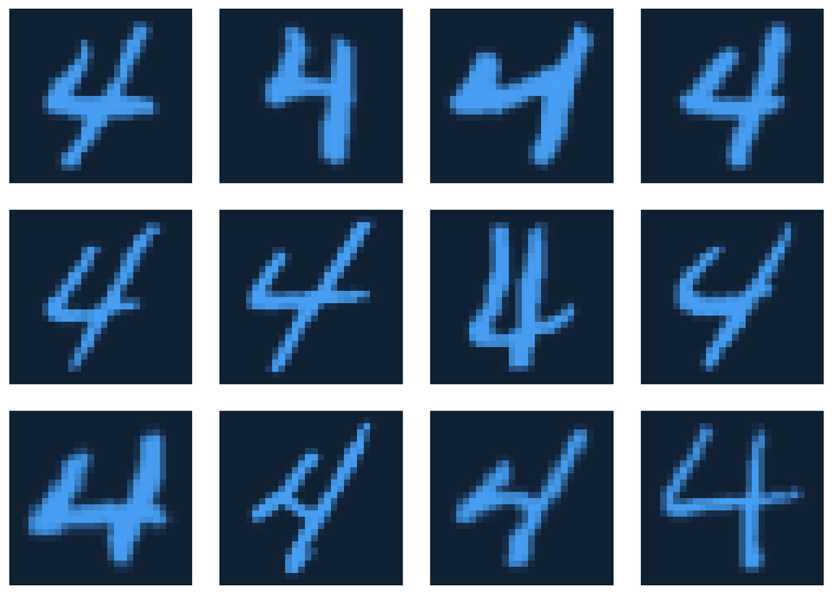

3. Perform a principal component analysis (PCA) on your data. How much variation does the first 5 principal components explain in the data? **(2 marks)**
4. Show what aspect of the data the first and second principal component loadings capture like the example plot below. **(2 marks)**

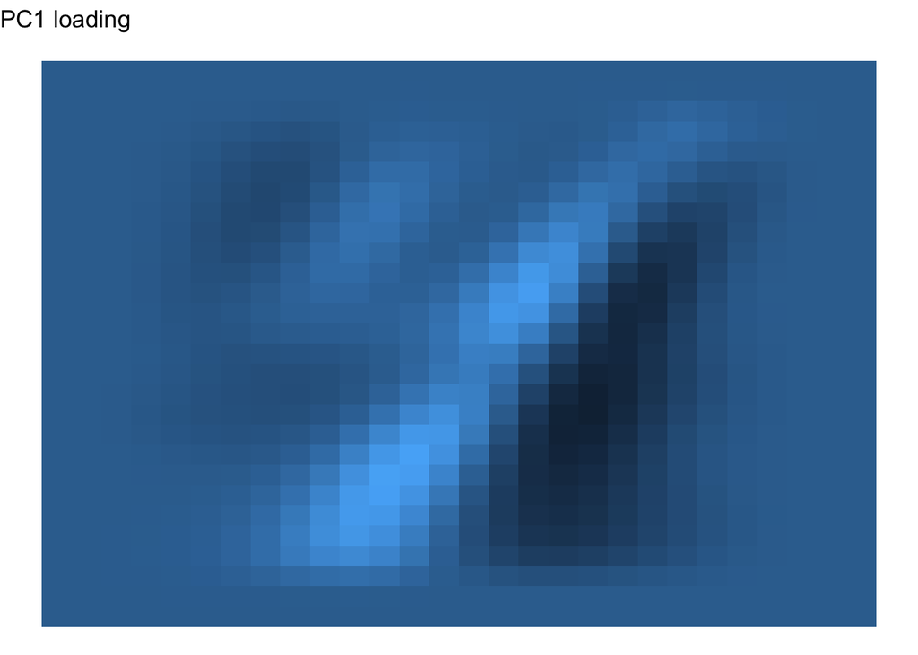

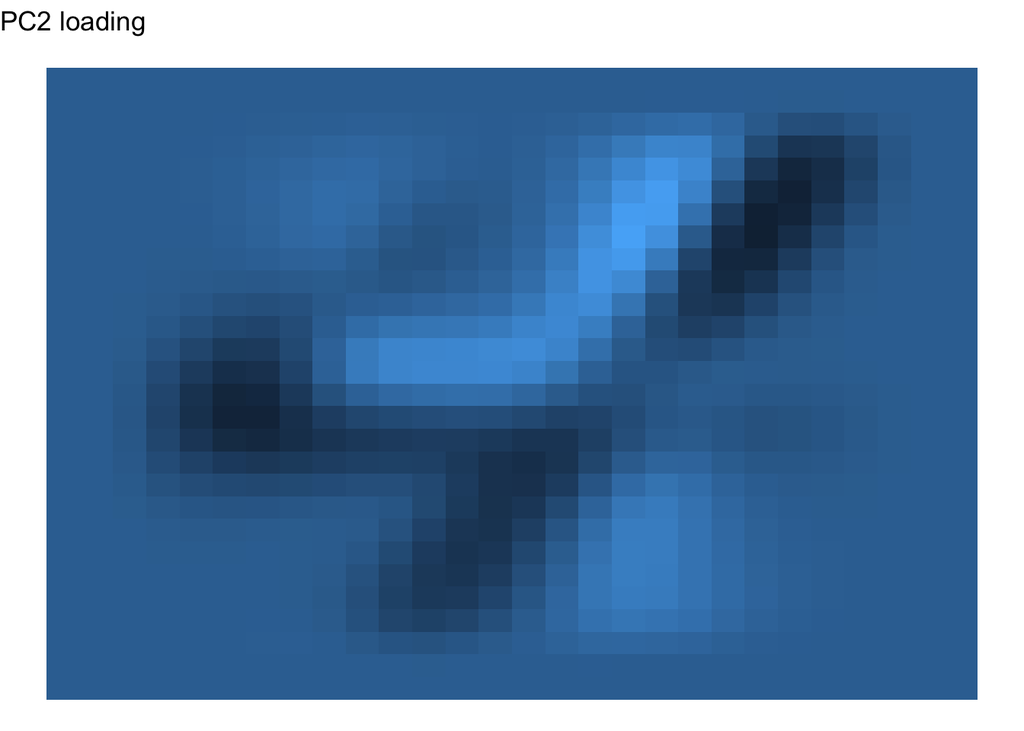

5. Using the rotated data from the PCA, perform an agglomerative hierarchical clustering with average linkage. **(2 marks)**
6. Cut the tree from question 5 to 4 clusters. Show how many observations you have per cluster. **(2 marks)**
7. Show a sample of 10 (or the total number of images in a cluster if less than 10 observations in a cluster) images from each cluster like the plot below. What do you notice about the cluster groups? **(3 marks)**

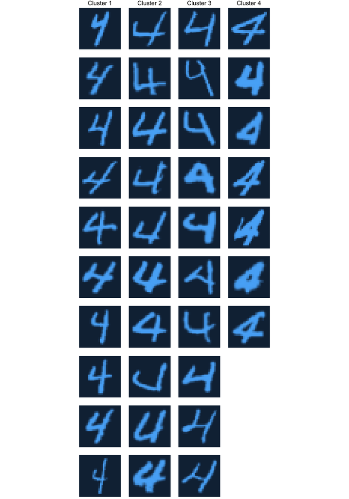

### Report

The fraud detection team at a company has commissioned you to profile the different possible ways a person can write a particular letter. Use your main data to come up with a sensible set of groups *based on the principal components of the main data*. Provide a high-level description of each group. *You must have at least 3 groups*.

The company also has a set of new record of 5 observations. Use supervised learning **with principal components as predictors** to classify these 5 observations into one of the groups you’ve made. You should try at least two methods and discuss how you selected which one was optimal.

Your findings should be written as a report with no more than 4 pages in total (print your HTML to PDF to see how many pages). You will be assessed on

- the justification of your profiling and how reasonable your profiling is (you should show sample images for each of your clusters), **(4 marks)**
- the use of concise and grammatically correct English and clear explanations, **(3 marks)**
- the justification of your model choice and how sensible your prediction for the new records are. **(10 marks)**

## 💯 Marks

- Total mark will be out of 35.
- **1 mark** will be reserved for readability, and appropriate citing of external sources.
- **2 marks** will be reserved for reproducibility, that the report can be re-generated from the submitted Rmarkdown.
- **1 mark** reserved for clean and readable code.
- Accuracy and completeness of answers, and clarity of explanations will be the basis for the remaining marks.